# Homework 2

Ruggeri D., Ercolino S., Tazza G.

25/5/2021

## Exercise 1: The Bayes Classifier

### 1. Bayes strategy

### 2. Bayes Classification Rule $h_{opt}(x)$

The Bayes classification rule $h_{opt}(x)$ for a binary classification (s.t. $Y \in \mathcal{Y} = \{0,1\}$) is given by:

$$h_{opt}(x) = \mathbb{I}\left[\mathbb{P}(Y = 1 ~ | ~\mathbf{X} = \mathbf{x}) > \frac{1}{2}\right]$$

Where (simplifying the notation for the $\mathbf{X}$), we have the Regression Function:
$$\mathbb{P}(Y = 1 ~ |~ \mathbf{X}) = (Bayes)= \frac{ \mathbb{P}(\mathbf{X} ~ | ~Y=1) \cdot \mathbb{P}(Y=1)}{\mathbb{P}(\mathbf X)} = \frac{ \mathbb{P}(\mathbf{X} ~ | ~Y=1) \cdot \mathbb{P}(Y=1)}{\mathbb{P}(\mathbf X ~ | ~Y=1)\cdot\mathbb{P}(Y=1) + \mathbb{P}(\mathbf X ~ | ~Y=0)\cdot\mathbb{P}(Y=0)}$$

Since we assume $(X,Y)$ r.v. with $Y \in \{0,1\}$ and $X \in \mathbb{R}$, having conditional distribution:
$$(X ~|~Y = 1) \sim Unif(-1, 3) ~~~ and~~~ (X ~|~Y = 0) \sim Unif(-3, 1)$$

and:
$$\mathbb{P}(Y=1)=\mathbb{P}(Y=0)= \frac{1}{2}$$

But, since the conditional distributions of $X$ are uniforms, we can rewrite the probabilities as:
$$\mathbb{P}(X ~|~Y = 1) = \frac{1}{4} \mathbb{I}_{[-1,3]} (x) ~~ and ~~ \mathbb{P}(X ~|~Y = 0) = \frac{1}{4} \mathbb{I}_{[-3,1]} (x)$$

So, by substituting the values, the Regression Function $\mathbb{P}(Y=1|X)$ for this classification problem becomes:

$$\mathbb{P}(Y=1~|~X) = \frac{\frac{1}{8} \mathbb{I}_{[-1,3]} (x)}{\frac{1}{8} \mathbb{I}_{[-3,1]}(x) + \frac{1}{8} \mathbb{I}_{[-1,3]}(x)} = \frac{ \mathbb{I}_{[-1,3]}(x)}{ \mathbb{I}_{[-3,1]}(x) + \mathbb{I}_{[-1,3]}(x)} = \frac{ \mathbb{I}_{[-1,1)}(x) + \mathbb{I}_{[1,3]}(x)}{ \mathbb{I}_{[-3,-1]}(x) + 2 \mathbb{I}_{[-1,1]}(x) + \mathbb{I}_{[1,3]}(x)} =$$
$$= \left\{\begin{array}{ll}
0 ~~ if ~~ -3\leq x < -1\\
\frac{1}{2} ~~ if ~~ -1\leq x < 1\\
1 ~~ if ~~ 1\leq x\leq 3
\end{array}
\right. \implies \\$$
$$\implies \mathbb{P} (Y=1~|~X) = \frac{1}{2} \mathbb{I}_{[-1,1)} + \mathbb{I}_{[1,3]}$$

And the classification rule $h_{opt}$ can be written as:
$$h_{opt}(x) = \mathbb{I}_\left[\mathbb{P}(Y = 1 ~ | ~ X) > \frac{1}{2}\right] (x) = \mathbb{I}_\left[ \frac{1}{2} \mathbb{I}_{[-1,1)} + \mathbb{I}_{[1,3]} > \frac{1}{2}\right] (x) = \mathbb{I}_{[1, 3]} (x)$$

Which means that the observations are classified as $y=1$ when the feature $X$ has values in $[1,3]$, and $y=0$ otherwise.

## Exercise 2: Go Gradient, Go!

Loading the dataset and encoding the responses right after:

```r
load("data/amazon_review_clean.RData")

# changing labels of y vectors to book = TRUE, movie = FALSE
y_tr = (y_tr == "book")
y_te = (y_te == "book")
```

Creating the validation dataset from train:

```r
val.indices = sample(seq(1, length(y_tr)), 50000, replace = F)
X_val = X_tr[val.indices, ]
y_val = y_tr[val.indices]
X_tr = X_tr[-val.indices, ]
y_tr = y_tr[-val.indices]
```

#### Gradient

Defining the gradient computation and computing the $X.y$ matrix in advance:

```r
# differentiation variables:
gradient = function(n, X, X.y, X.t.beta){
    1/n * (t(X) %*% (1/(1+exp(-X.t.beta))) - X.y)
}

X.y = t(X_tr)%*%y_tr
```

#### Parameters

Now is time to initialize the parameters and hyper parameters:

```r
# regression parameters
beta = rnorm(ncol(X_tr), sd=0.1)

# hyper parameters:
alpha = 0.4 # learning rate
tolerance = 0.00001 # tolerance for the convergence condition
epochs = 500 # early stop on iterations

n = nrow(X_tr)
```

#### Starting the training with the Gradient Descent

```r
it = 1
continue = T
while (continue) {

  # updating the parameters
  beta = beta - alpha * gradient(n=nrow(X_tr), X_tr, X.y, X.t.beta)
  X.t.beta = X_tr%*%beta
  X.v.beta = X_val%*%beta
  old.val.loss = val.loss
  loss = 1/n * sum(log(1+exp(X.t.beta)) - y_tr*X.t.beta)
  val.loss <- 1/n * sum(log(1+exp(X.v.beta)) - y_val*X.v.beta)

  # logging the metrics for plotting
  loss.hist <- cbind(loss.hist, c(loss))
  val.hist <- cbind(val.hist, c(val.loss))
  train.acc = Accuracy(y_pred = X.t.beta>0, y_true = y_tr)
  val.acc = Accuracy(y_pred = X.v.beta>0, y_true = y_val)
  train.accs <- cbind(train.accs, c(train.acc))
  val.accs <- cbind(val.accs, c(val.acc))

  # conditions for stop iterating
  if (((it>50) && (old.val.loss <= val.loss + tolerance)) || (it>epochs)){continue = F}
  it = it + 1
}
```

### Plots

Here the descending curves:

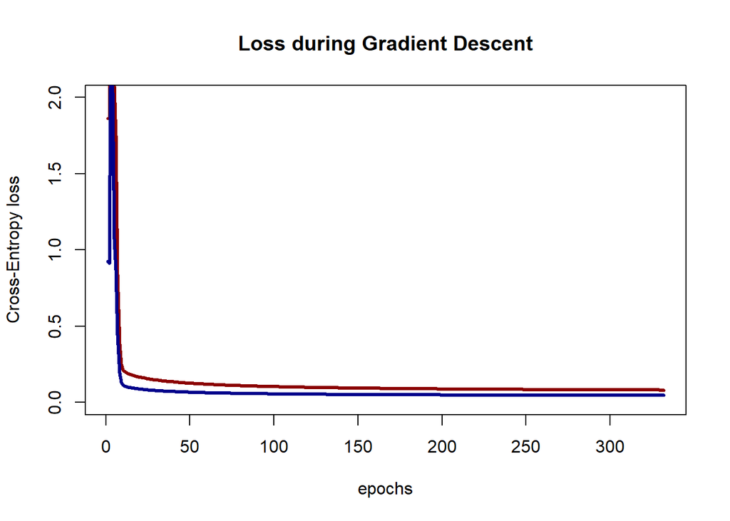

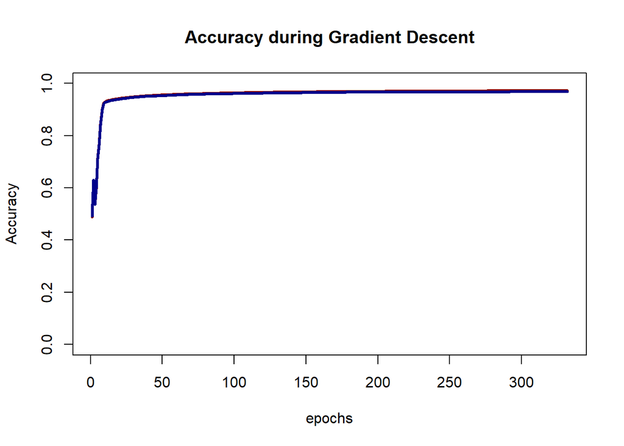